# GLIM_Featurization_Assignment

## Import Libraries

```python
import pandas as pd
import numpy as np
import seaborn as sns
import warnings
warnings.simplefilter("ignore")
import matplotlib.pyplot as plt
%matplotlib inline
from scipy.stats import zscore
from statsmodels.stats.outliers_influence import variance_inflation_factor
from sklearn.model_selection import train_test_split
from scipy.spatial.distance import cdist
from sklearn.metrics import silhouette_score
from sklearn.cluster import KMeans
from sklearn import metrics
from sklearn import tree
from sklearn.model_selection import GridSearchCV
from sklearn.svm import SVR
from sklearn import ensemble
from sklearn import linear_model
from sklearn.preprocessing import PolynomialFeatures
from sklearn.pipeline import Pipeline
from sklearn.model_selection import KFold
from sklearn.model_selection import cross_val_score
```

## Import the data

```python
concrete = pd.read_csv("concrete.csv")
```

## Read the data

```python
concrete.head()
```

|  | cement | slag | ash | water | superplastic | coarseagg | fineagg | age | strength |
| --- | --- | --- | --- | --- | --- | --- | --- | --- | --- |
| 0 | 141.3 | 212.0 | 0.0 | 203.5 | 0.0 | 971.8 | 748.5 | 28 | 29.89 |
| 1 | 168.9 | 42.2 | 124.3 | 158.3 | 10.8 | 1080.8 | 796.2 | 14 | 23.51 |
| 2 | 250.0 | 0.0 | 95.7 | 187.4 | 5.5 | 956.9 | 861.2 | 28 | 29.22 |
| 3 | 266.0 | 114.0 | 0.0 | 228.0 | 0.0 | 932.0 | 670.0 | 28 | 45.85 |
| 4 | 154.8 | 183.4 | 0.0 | 193.3 | 9.1 | 1047.4 | 696.7 | 28 | 18.29 |

## Data shape, info and types

There are 1030 rows and 9 columns. All are either float or int and no objects

```python
concrete.shape
```

```
(1030, 9)
```

```python
concrete.info()
```

```
<class 'pandas.core.frame.DataFrame'>
RangeIndex: 1030 entries, 0 to 1029
Data columns (total 9 columns):
cement          1030 non-null float64
slag            1030 non-null float64
ash             1030 non-null float64
water           1030 non-null float64
superplastic    1030 non-null float64
coarseagg       1030 non-null float64
fineagg         1030 non-null float64
age             1030 non-null int64
strength        1030 non-null float64
dtypes: float64(8), int64(1)
memory usage: 72.5 KB
```

```python
concrete.dtypes
```

```
cement          float64
slag            float64
ash             float64
water           float64
superplastic    float64
coarseagg       float64
fineagg         float64
age               int64
strength        float64
dtype: object
```

## Find missing values

There are no missing values, but we need to find out from each column if there is any value with 0

```python
concrete.isnull().sum()
```

```
cement          0
slag            0
ash             0
water           0
superplastic    0
coarseagg       0
fineagg         0
age             0
strength        0
dtype: int64
```

```python
zeroval = pd.DataFrame() #Create a DataFrame to store the number of records having '0' as the value
def zero(dataframe): #Create a function which returns the dataframe of records having '0' as the value
    for column in dataframe.columns:
        zeroval.set_value(0,column,dataframe[dataframe[column] == 0].shape[0])
        zeroval[column] = zeroval[column].astype('int64')
    return zeroval
zero(concrete)#Displays the dataframe with the column names and number of records with value '0'
```

|  | cement | slag | ash | water | superplastic | coarseagg | fineagg | age | strength |
| --- | --- | --- | --- | --- | --- | --- | --- | --- | --- |
| 0 | 0 | 471 | 566 | 0 | 379 | 0 | 0 | 0 | 0 |

### Find Median and fill the values

```python
data = concrete.copy() #Create another copy of the dataframe
```

```python
medianval = pd.DataFrame() #Create a dataframe to store the median values of all columns
def median(dataframe): #Define a function which returns a dataframe with the median values
    for column in dataframe.columns:
        medianval.set_value(0,column,dataframe[column].median())
        medianval[column] = medianval[column].astype('float64')
    return medianval
median(data) #Displays the dataframe containing the median values
```

|  | cement | slag | ash | water | superplastic | coarseagg | fineagg | age | strength |
| --- | --- | --- | --- | --- | --- | --- | --- | --- | --- |
| 0 | 272.9 | 22.0 | 0.0 | 185.0 | 6.4 | 968.0 | 779.5 | 28.0 | 34.445 |

```python
def fillmedian(dataframe): #Create a function which returns the dataframe with the median values for values '0'
    for column in dataframe.columns:
        dataframe[column] = dataframe[column].apply(lambda x: np.where(x == 0, dataframe[column].median(), x))
    return dataframe
fillmedian(data) #Displays the dataframe with the median values updated
```

|  | cement | slag | ash | water | superplastic | coarseagg | fineagg | age | strength |
| --- | --- | --- | --- | --- | --- | --- | --- | --- | --- |
| 0 | 141.3 | 212.0 | 0.0 | 203.5 | 6.4 | 971.8 | 748.5 | 28.0 | 29.89 |
| 1 | 168.9 | 42.2 | 124.3 | 158.3 | 10.8 | 1080.8 | 796.2 | 14.0 | 23.51 |
| 2 | 250.0 | 22.0 | 95.7 | 187.4 | 5.5 | 956.9 | 861.2 | 28.0 | 29.22 |
| 3 | 266.0 | 114.0 | 0.0 | 228.0 | 6.4 | 932.0 | 670.0 | 28.0 | 45.85 |
| 4 | 154.8 | 183.4 | 0.0 | 193.3 | 9.1 | 1047.4 | 696.7 | 28.0 | 18.29 |
| ... | ... | ... | ... | ... | ... | ... | ... | ... | ... |
| 1025 | 135.0 | 22.0 | 166.0 | 180.0 | 10.0 | 961.0 | 805.0 | 28.0 | 13.29 |
| 1026 | 531.3 | 22.0 | 0.0 | 141.8 | 28.2 | 852.1 | 893.7 | 3.0 | 41.30 |
| 1027 | 276.4 | 116.0 | 90.3 | 179.6 | 8.9 | 870.1 | 768.3 | 28.0 | 44.28 |
| 1028 | 342.0 | 38.0 | 0.0 | 228.0 | 6.4 | 932.0 | 670.0 | 270.0 | 55.06 |
| 1029 | 540.0 | 22.0 | 0.0 | 173.0 | 6.4 | 1125.0 | 613.0 | 7.0 | 52.61 |

1030 rows × 9 columns

```python
zero(data) #Check if there are still any column with value '0'
```

|  | cement | slag | ash | water | superplastic | coarseagg | fineagg | age | strength |
| --- | --- | --- | --- | --- | --- | --- | --- | --- | --- |
| 0 | 0 | 0 | 566 | 0 | 0 | 0 | 0 | 0 | 0 |

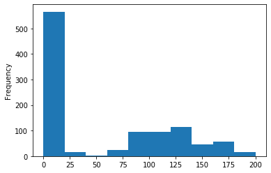

```python
data['ash'].plot(kind = 'hist') #We find that for 'ash', a very large number of records have '0' as value
```

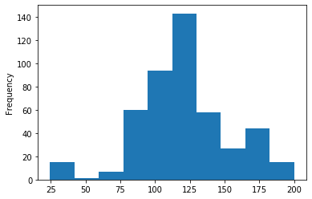

```python
data[data['ash'] != 0]['ash'].plot(kind = 'hist') #Histogram with removing the value '0'
```

```python
data[data['ash'] != 0]['ash'].median() #Median value of 'ash' without considering the values '0'
```

```
121.4
```

```python
data['ash'] = data['ash'].apply(lambda x: np.where(x == 0, data[data['ash'] != 0]['ash'].median(), x))
```

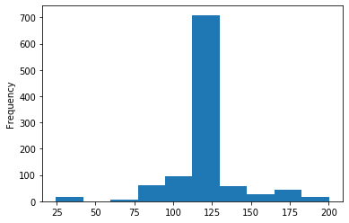

```python
data['ash'].plot(kind = 'hist') #Histogram after applying the median transformation
```

```python
zero(data)#Recheck if there are any values with '0'. We dont find any and we are clear to go to EDA
```

|  | cement | slag | ash | water | superplastic | coarseagg | fineagg | age | strength |
| --- | --- | --- | --- | --- | --- | --- | --- | --- | --- |
| 0 | 0 | 0 | 0 | 0 | 0 | 0 | 0 | 0 | 0 |

## Univariate Analysis

### Box Plot

Cement & Courseagg independent variables have not outliers  
Rest of the independent variables have outliers

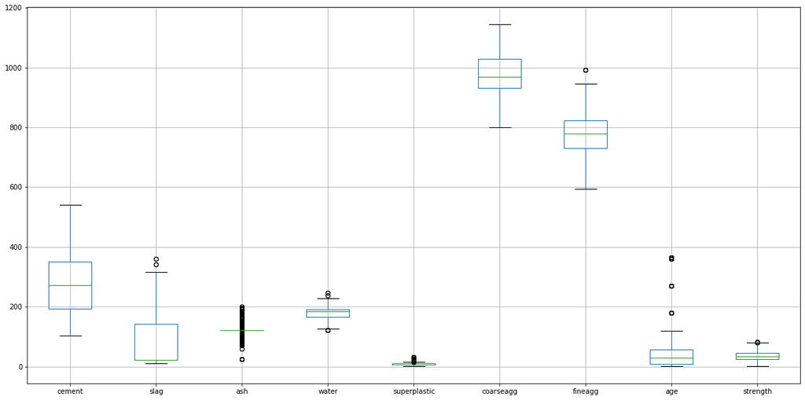

```python
plt.figure(figsize = (20,10))
data.boxplot()
```

### Histogram of all independent variables

```
array([[<matplotlib.axes._subplots.AxesSubplot object at 0x11e1016d8>,
      dtype=object)
```

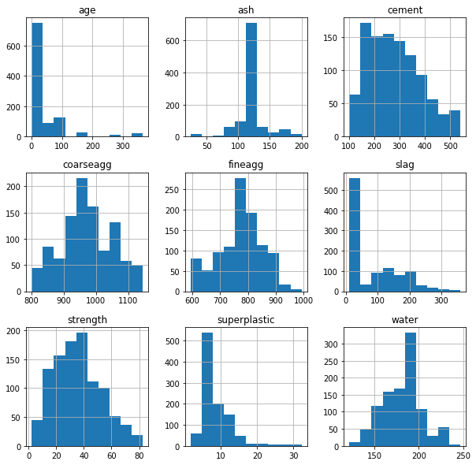

```python
data.hist(figsize = (10,10))
```

### Correlation in the dataframe

Cement has 0.5 correlation with Strength  
Superplastic and Age have almost 0.32 positive correlation with Strength  
Cement, Slag, Superplastic & Age have a positive correlation with Strength.  
Ash, Water, Coarseagg, Fineagg have a negative correlation with Strength

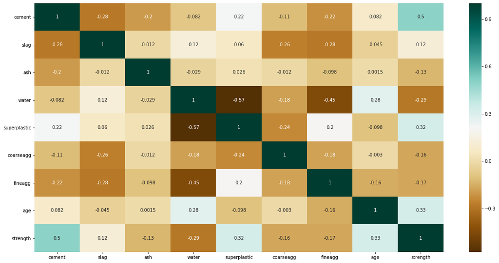

```python
plt.figure(figsize = (20,10))
sns.heatmap(data.corr(), cmap = 'BrBG', annot = True)
```

### 5 Point Analysis

Cement is evenly distributed as visualized through the histogram and boxplot  
Slag has a max value of 359, but the median is at 22. The distribution is right skewed  
Ash has been biased with median value as 121 after treating the values with '0'  
Water looks like a normally distributed with a shorter range values than most other independent variables  
Superplastic also like water seems to have a shorter range values  
Coarseagg is normally distributed and does not have any outliers  
Fineagg is also normally distributed and has outliers  
Age variable does not have any distribution and have many discrete values  
Strength is also normally distributed and lightly right skewed

```python
data.describe(include = 'all').transpose().round()
```

|  | count | mean | std | min | 25% | 50% | 75% | max |
| --- | --- | --- | --- | --- | --- | --- | --- | --- |
| cement | 1030.0 | 281.0 | 105.0 | 102.0 | 192.0 | 273.0 | 350.0 | 540.0 |
| slag | 1030.0 | 84.0 | 78.0 | 11.0 | 22.0 | 22.0 | 143.0 | 359.0 |
| ash | 1030.0 | 121.0 | 23.0 | 24.0 | 121.0 | 121.0 | 121.0 | 200.0 |
| water | 1030.0 | 182.0 | 21.0 | 122.0 | 165.0 | 185.0 | 192.0 | 247.0 |
| superplastic | 1030.0 | 9.0 | 4.0 | 2.0 | 6.0 | 6.0 | 10.0 | 32.0 |
| coarseagg | 1030.0 | 973.0 | 78.0 | 801.0 | 932.0 | 968.0 | 1029.0 | 1145.0 |
| fineagg | 1030.0 | 774.0 | 80.0 | 594.0 | 731.0 | 780.0 | 824.0 | 993.0 |
| age | 1030.0 | 46.0 | 63.0 | 1.0 | 7.0 | 28.0 | 56.0 | 365.0 |
| strength | 1030.0 | 36.0 | 17.0 | 2.0 | 24.0 | 34.0 | 46.0 | 83.0 |

### Distplot for all independent variables

Cement has a normal distribution with one gaussian possibility  
Slag possibly has two gaussians  
Ash has possibly one gaussian  
Water has possibly three gaussians  
Superplastic has possibly two or three gaussians  
Courseagg has possibly three gaussians  
Fineagg has possibly three gaussians  
Age possibly has five gaussians  
Strength has a normal distribution with one gaussian possibility

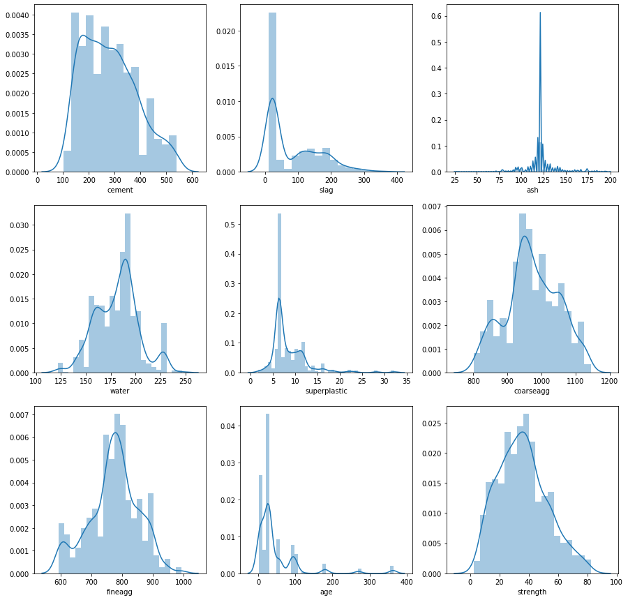

```python
fig, ax = plt.subplots(3,3,figsize = (15,15))
sns.distplot(data['cement'], ax = ax[0][0])
sns.distplot(data['slag'], ax = ax[0][1])
sns.distplot(data['ash'], ax = ax[0][2])
sns.distplot(data['water'], ax = ax[1][0])
sns.distplot(data['superplastic'], ax = ax[1][1])
sns.distplot(data['coarseagg'], ax = ax[1][2])
sns.distplot(data['fineagg'], ax = ax[2][0])
sns.distplot(data['age'], ax = ax[2][1])
sns.distplot(data['strength'], ax = ax[2][2])
```

## Multivariate Analysis

### Regplot for each independent variable to the dependent variable (Strength)

Cement has a positive correlation and the data points are packed and somewhat close to the best fit line  
Slag has a positive correlation but the data points are spread out indicating a less correlation to Strength  
Ash has a negative correlation but the data points are spread out indicating a less correlation to Strength  
Water has a negative correlation but the data points are spread out indicating a less correlation to Strength  
Superplastic has a positive correlation but the data points are packed out indicating a good correlation to Strength  
Coarseagg has a negative correlation but the data points are spread out indicating a less correlation to Strength  
Fineagg has a negative correlation but the data points are spread out indicating a less correlation to Strength  
Age seems to have multiple discrete values and seems to be a non-linear fit

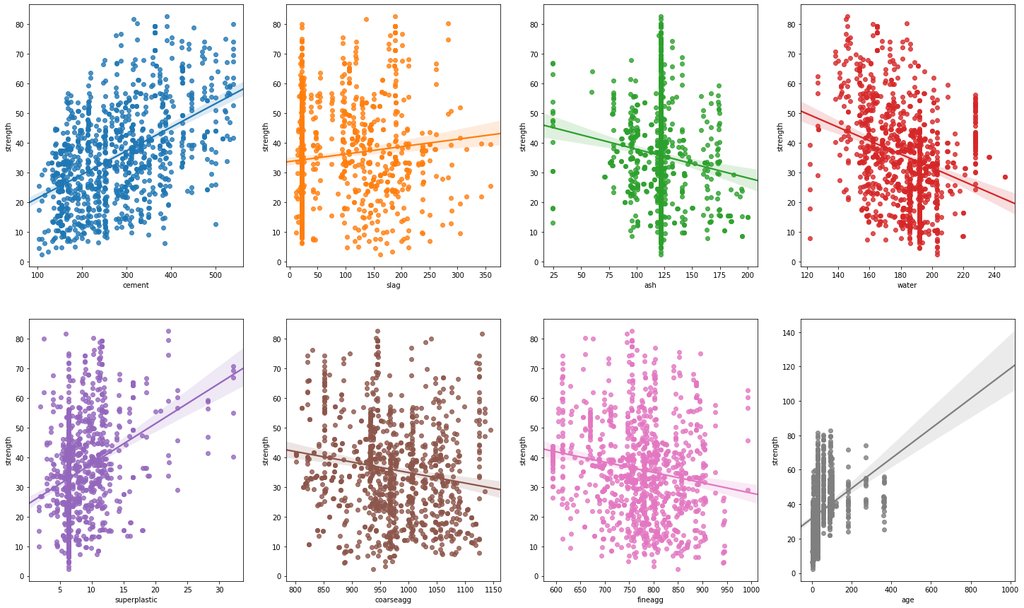

```python
fig, ax = plt.subplots(2,4,figsize = (25,15))
sns.regplot(data['cement'], data['strength'], ax = ax[0][0])
sns.regplot(data['slag'], data['strength'], ax = ax[0][1])
sns.regplot(data['ash'], data['strength'], ax = ax[0][2])
sns.regplot(data['water'], data['strength'], ax = ax[0][3])
sns.regplot(data['superplastic'], data['strength'], ax = ax[1][0])
sns.regplot(data['coarseagg'], data['strength'], ax = ax[1][1])
sns.regplot(data['fineagg'], data['strength'], ax = ax[1][2])
sns.regplot(data['age'], data['strength'], ax = ax[1][3])
```

### Pairplot

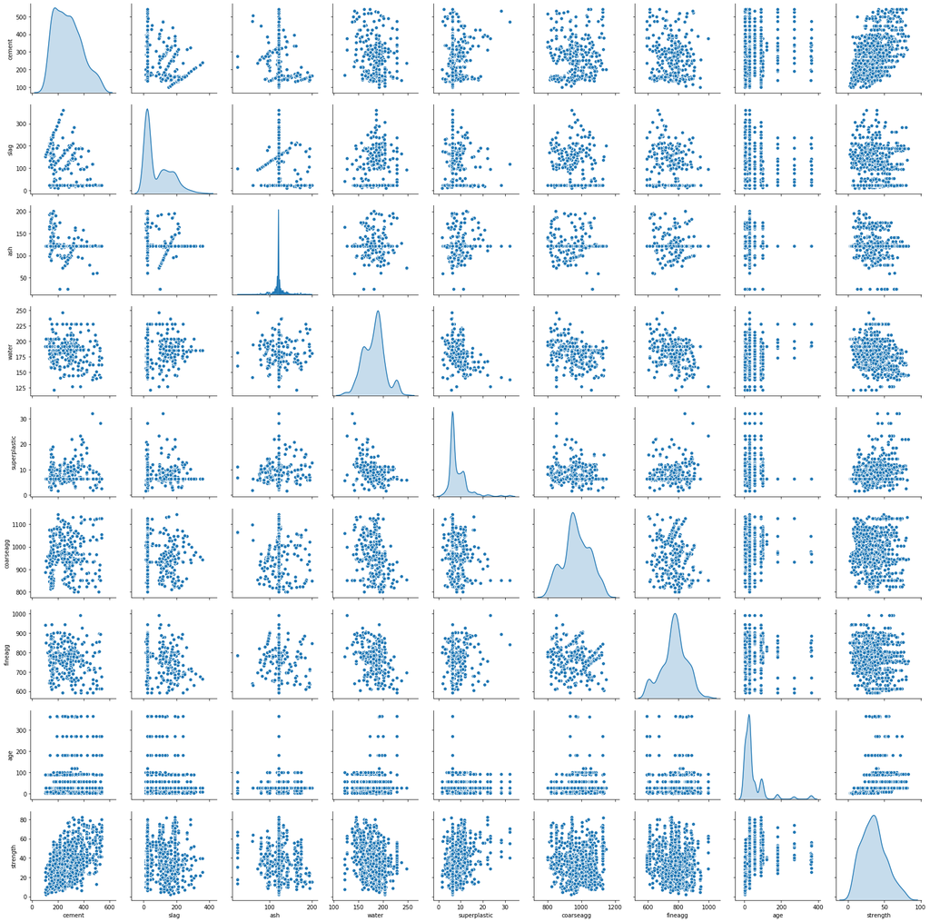

```python
sns.pairplot(data, diag_kind = 'kde')
```

## Outlier processing

We will identify the outliers and replace them with the respective median values

```python
def outliers(dataframe): #Define a function for the outlier processing through the IQR method
    for column in dataframe.columns[:-1]:
        q1 = dataframe[column].quantile(0.25)
        q3 = dataframe[column].quantile(0.75)
        iqr = q3 - q1
        low = q1 - 1.5*iqr
        high = q3 + 1.5*iqr
        dataframe.loc[(dataframe[column] < low) | (dataframe[column] > high), column] = dataframe[column].median()
    return dataframe #Returns the dataframe after outlier processing through the IQR method
outliers(data)
```

|  | cement | slag | ash | water | superplastic | coarseagg | fineagg | age | strength |
| --- | --- | --- | --- | --- | --- | --- | --- | --- | --- |
| 0 | 141.3 | 212.0 | 121.4 | 203.5 | 6.4 | 971.8 | 748.5 | 28.0 | 29.89 |
| 1 | 168.9 | 42.2 | 121.4 | 158.3 | 10.8 | 1080.8 | 796.2 | 14.0 | 23.51 |
| 2 | 250.0 | 22.0 | 121.4 | 187.4 | 5.5 | 956.9 | 861.2 | 28.0 | 29.22 |
| 3 | 266.0 | 114.0 | 121.4 | 228.0 | 6.4 | 932.0 | 670.0 | 28.0 | 45.85 |
| 4 | 154.8 | 183.4 | 121.4 | 193.3 | 9.1 | 1047.4 | 696.7 | 28.0 | 18.29 |
| ... | ... | ... | ... | ... | ... | ... | ... | ... | ... |
| 1025 | 135.0 | 22.0 | 121.4 | 180.0 | 10.0 | 961.0 | 805.0 | 28.0 | 13.29 |
| 1026 | 531.3 | 22.0 | 121.4 | 141.8 | 6.4 | 852.1 | 893.7 | 3.0 | 41.30 |
| 1027 | 276.4 | 116.0 | 121.4 | 179.6 | 8.9 | 870.1 | 768.3 | 28.0 | 44.28 |
| 1028 | 342.0 | 38.0 | 121.4 | 228.0 | 6.4 | 932.0 | 670.0 | 28.0 | 55.06 |
| 1029 | 540.0 | 22.0 | 121.4 | 173.0 | 6.4 | 1125.0 | 613.0 | 7.0 | 52.61 |

1030 rows × 9 columns

### Boxplot after outlier processing

We find that most of the independent variables are free of outliers now.

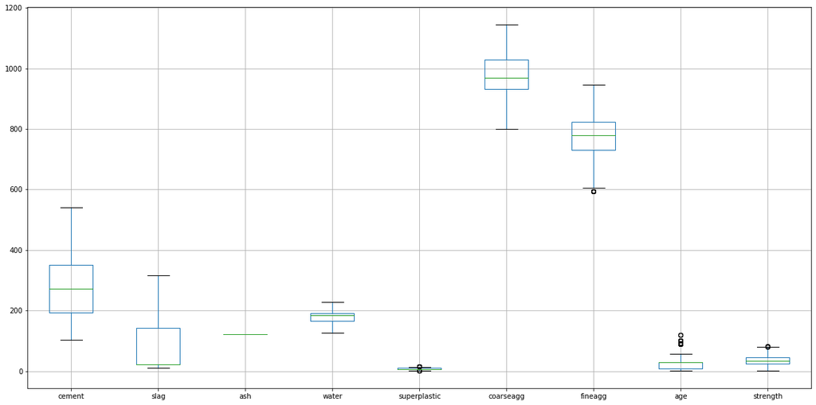

```python
plt.figure(figsize = (20,10))
data.boxplot()
```

## Feature Engineering

Q. Identify opportunities (if any) to create a composite feature, drop a feature etc.

We will do so using VIF and later in the code using PCA and also feature importance through Decision Tree

### Variance Inflation Factor

We find that "Ash" has a very big value of VIF and shows a high collinearity. We can discard this variable before our regression model is fit.

```python
def vif(dataframe):
    vif = pd.DataFrame()
    vif['VIF Factor'] = [variance_inflation_factor(dataframe.values, i) for i in range(dataframe.shape[1])]
    vif['Features'] = dataframe.columns
    return vif
vif(data)
```

|  | VIF Factor | Features |
| --- | --- | --- |
| 0 | 2.340275 | cement |
| 1 | 1.763822 | slag |
| 2 | 1661.641833 | ash |
| 3 | 2.413803 | water |
| 4 | 1.352893 | superplastic |
| 5 | 1.643155 | coarseagg |
| 6 | 2.256264 | fineagg |
| 7 | 1.929567 | age |
| 8 | 3.444633 | strength |

### Drop Variables

We will drop "Ash" from the original dataset

```python
dataz = data.drop("ash", axis = 1)
```

### Explore for Gaussians by making clusters in the training data

Q. Explore for gaussians. If data is likely to be a mix of gaussians, explore individual clusters and present your findings in terms of the independent attributes and their suitability to predict strength

We will take n_clusters = 4

```
For Cluster = 2, the Silhouette Score is 0.2560
For Cluster = 3, the Silhouette Score is 0.2678
For Cluster = 4, the Silhouette Score is 0.2797
For Cluster = 5, the Silhouette Score is 0.2782
For Cluster = 6, the Silhouette Score is 0.2666
For Cluster = 7, the Silhouette Score is 0.2778
For Cluster = 8, the Silhouette Score is 0.2814
For Cluster = 9, the Silhouette Score is 0.2821
```

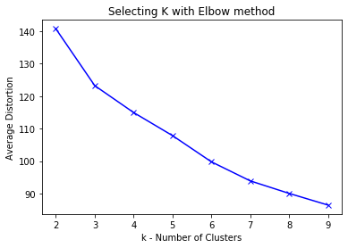

```python
def cluster(dataframe):
    clusters = range(2,10)
    mean_distortion = []
    for k in clusters:
        model = KMeans(n_clusters= k)
        model.fit(dataframe)
        prediction = model.predict(dataframe)
        mean_distortion.append(sum(np.min(cdist(dataframe, model.cluster_centers_, 'euclidean'), axis = 1))/dataframe.shape[0])
        print("For Cluster = %i, the Silhouette Score is %1.4f" %(k, silhouette_score(dataframe, model.labels_)))
    plt.plot(clusters, mean_distortion, 'bx-')
    plt.xlabel('k - Number of Clusters')
    plt.ylabel('Average Distortion')
    plt.title('Selecting K with Elbow method')
cluster(dataz)
```

```python
cluster = 4
def kmeans(dataframe, n_cluster):
    model = KMeans(n_clusters=cluster)
    model.fit(dataframe)
    prediction = model.predict(dataframe)
    return prediction
predictions = kmeans(dataz, cluster)
```

```python
def addcluster(dataframe, labels):
    dataframe['cluster'] = labels
    return dataframe
dataz = addcluster(dataz, predictions)
```

```python
dataz
```

|  | cement | slag | water | superplastic | coarseagg | fineagg | age | strength | cluster |
| --- | --- | --- | --- | --- | --- | --- | --- | --- | --- |
| 0 | 141.3 | 212.0 | 203.5 | 6.4 | 971.8 | 748.5 | 28.0 | 29.89 | 1 |
| 1 | 168.9 | 42.2 | 158.3 | 10.8 | 1080.8 | 796.2 | 14.0 | 23.51 | 2 |
| 2 | 250.0 | 22.0 | 187.4 | 5.5 | 956.9 | 861.2 | 28.0 | 29.22 | 2 |
| 3 | 266.0 | 114.0 | 228.0 | 6.4 | 932.0 | 670.0 | 28.0 | 45.85 | 1 |
| 4 | 154.8 | 183.4 | 193.3 | 9.1 | 1047.4 | 696.7 | 28.0 | 18.29 | 1 |
| ... | ... | ... | ... | ... | ... | ... | ... | ... | ... |
| 1025 | 135.0 | 22.0 | 180.0 | 10.0 | 961.0 | 805.0 | 28.0 | 13.29 | 2 |
| 1026 | 531.3 | 22.0 | 141.8 | 6.4 | 852.1 | 893.7 | 3.0 | 41.30 | 3 |
| 1027 | 276.4 | 116.0 | 179.6 | 8.9 | 870.1 | 768.3 | 28.0 | 44.28 | 3 |
| 1028 | 342.0 | 38.0 | 228.0 | 6.4 | 932.0 | 670.0 | 28.0 | 55.06 | 0 |
| 1029 | 540.0 | 22.0 | 173.0 | 6.4 | 1125.0 | 613.0 | 7.0 | 52.61 | 0 |

1030 rows × 9 columns

### Make separate dataframes to each cluster formed

For each of the 4 clusters, we will seperate them to individual dataframes

```python
def dfclusters(dataframe):
    X_C0 = dataframe[dataframe['cluster'] == 0]
    X_C1 = dataframe[dataframe['cluster'] == 1]
    X_C2 = dataframe[dataframe['cluster'] == 2]
    X_C3 = dataframe[dataframe['cluster'] == 3]
    return X_C0, X_C1, X_C2, X_C3
data_C0, data_C1, data_C2, data_C3 = dfclusters(dataz)

print(data_C0.shape, data_C1.shape, data_C2.shape, data_C3.shape)
```

```
(133, 9) (268, 9) (400, 9) (229, 9)
```

### Separate the independent and dependent variables

```python
columns=['strength', 'cluster']
def separate(dataframe):
    X = dataframe.drop(columns, axis = 1)
    y = dataframe['strength']
    return X, y
X_C0, y_C0 = separate(data_C0)
X_C1, y_C1 = separate(data_C1)
X_C2, y_C2 = separate(data_C2)
X_C3, y_C3 = separate(data_C3)
```

### Standardize the training, validation and test datasets

```python
def standardize(dataframe):
    dataframe = zscore(dataframe)
    return dataframe
```

### Creating a dataframe after Standardization

```python
def makedataframe(dataframe):
    X = pd.DataFrame(dataframe)
    X.columns = dataz.columns[:-2]
    return X
```

```python
X = dataz.columns[:-2]
y = ['strength']
```

### Data Split, apply models and returns the R2 score of the models in form of a dataframe

Q. Algorithms that you think will be suitable for this project

We will use OLS, Lasso, Ridge, Decision Tree, Random Forest and Bagging Regressor models

```python
def test(models, data, iterations = 10):
    results = {}
    for i in models:
        r2_train = []
        r2_test = []
        for j in range(iterations):
            X_train, X_test, y_train, y_test = train_test_split(data[X], data[y], test_size = 0.3)
            r2_train.append(metrics.r2_score(y_train, models[i].fit(X_train, y_train).predict(X_train)))
            r2_test.append(metrics.r2_score(y_test, models[i].fit(X_train, y_train).predict(X_test)))
        results[i] = [np.mean(r2_train), np.mean(r2_test)]
    return pd.DataFrame(results)
```

```python
models = {'OLS': linear_model.LinearRegression(),
         'Lasso': linear_model.Lasso(),
         'Ridge': linear_model.Ridge(),
         'DecisionTreeRegressor' : tree.DecisionTreeRegressor(),
         'RandomForestRegressor': ensemble.RandomForestRegressor(),
          'BaggingRegressor': ensemble.BaggingRegressor()
         }
```

### Results for each cluster from 0 to 3

0 - Training Score  
1 - Testing Score  
Random Forest algo does a good job considering average of 80% accuracy for all the clusters

```python
test(models, data_C0)
```

|  | OLS | Lasso | Ridge | DecisionTreeRegressor | RandomForestRegressor | BaggingRegressor |
| --- | --- | --- | --- | --- | --- | --- |
| 0 | 0.416502 | 0.408138 | 0.413385 | 0.982698 | 0.952755 | 0.943876 |
| 1 | 0.317511 | 0.335152 | 0.329101 | 0.684178 | 0.743591 | 0.726305 |

```python
test(models, data_C1)
```

|  | OLS | Lasso | Ridge | DecisionTreeRegressor | RandomForestRegressor | BaggingRegressor |
| --- | --- | --- | --- | --- | --- | --- |
| 0 | 0.625938 | 0.634884 | 0.635743 | 0.992700 | 0.966238 | 0.956985 |
| 1 | 0.591434 | 0.547533 | 0.560261 | 0.671788 | 0.815471 | 0.782126 |

```python
test(models, data_C2)
```

|  | OLS | Lasso | Ridge | DecisionTreeRegressor | RandomForestRegressor | BaggingRegressor |
| --- | --- | --- | --- | --- | --- | --- |
| 0 | 0.768335 | 0.762983 | 0.768359 | 0.996773 | 0.977783 | 0.969466 |
| 1 | 0.758036 | 0.759224 | 0.755178 | 0.768240 | 0.853481 | 0.839940 |

```python
test(models, data_C3)
```

|  | OLS | Lasso | Ridge | DecisionTreeRegressor | RandomForestRegressor | BaggingRegressor |
| --- | --- | --- | --- | --- | --- | --- |
| 0 | 0.705680 | 0.701346 | 0.705123 | 0.987508 | 0.969204 | 0.960137 |
| 1 | 0.646455 | 0.656654 | 0.648984 | 0.713481 | 0.832823 | 0.825241 |

### Repeating the regression methods for the entire dataframe without spliting to clusters

0 - Training score  
1 - Testing score

Random Forest and Bagging Regressor has a good accuracy, but these are models without any hyperparameters tuned

```python
test(models, dataz)
```

|  | OLS | Lasso | Ridge | DecisionTreeRegressor | RandomForestRegressor | BaggingRegressor |
| --- | --- | --- | --- | --- | --- | --- |
| 0 | 0.712323 | 0.706303 | 0.704291 | 0.993280 | 0.980643 | 0.973914 |
| 1 | 0.697762 | 0.708155 | 0.718181 | 0.806451 | 0.887938 | 0.880803 |

### Grid Search for all Regressors

Q. Techniques employed to squeeze that extra performance out of the model without making it overfit or underfit

We will subject the data to hyperparameters and tune it to get the best performance

```python
lasso_params = {'alpha':[0.01, 0.1,1,10]}
ridge_params = {'alpha':[0.01, 0.1,1,10]}
tree_params = {'max_depth': [3,4,5]}
forest_params = {'max_depth': [3,4,5]}
bagging_params = {'max_features' : [3,4,5], 'n_estimators' : [10,25,50]}

models2 = {'OLS': linear_model.LinearRegression(),
           'Lasso': GridSearchCV(linear_model.Lasso(),
                               param_grid=lasso_params).fit(dataz[X], dataz[y]).best_estimator_,
           'Ridge': GridSearchCV(linear_model.Ridge(),
                               param_grid=ridge_params).fit(dataz[X], dataz[y]).best_estimator_,
            'DecisionTreeRegressor': GridSearchCV(tree.DecisionTreeRegressor(),
                               param_grid=tree_params).fit(dataz[X], dataz[y]).best_estimator_,
            'RandomForestRegressor': GridSearchCV(ensemble.RandomForestRegressor(),
                               param_grid=forest_params).fit(dataz[X], dataz[y]).best_estimator_,
           'BaggingRegressor': GridSearchCV(ensemble.BaggingRegressor(),
                               param_grid=bagging_params).fit(dataz[X], dataz[y]).best_estimator_,
          }
```

### Accuracy after Hyperparameters Tuned

We find that Random Forest and Bagging Regressor gives us a good result

```python
test(models2, dataz)
```

|  | OLS | Lasso | Ridge | DecisionTreeRegressor | RandomForestRegressor | BaggingRegressor |
| --- | --- | --- | --- | --- | --- | --- |
| 0 | 0.712558 | 0.707319 | 0.710618 | 0.822376 | 0.871540 | 0.948305 |
| 1 | 0.697997 | 0.710228 | 0.703057 | 0.722789 | 0.813271 | 0.850822 |

### PCA

```python
A = dataz[X]
b = dataz['strength']

from sklearn.decomposition import PCA
def pca(components, dataframe):
    pca = PCA(n_components = components, random_state = 0)
    pca_X = pca.fit_transform(A)
    return pca_X
pca_A =  pca(6,A)
```

```python
pca_A = pd.DataFrame(pca_A)
pca_A = pca_A.join(b)
```

```python
C = pca_A.columns[:-1]
d = ['strength']
```

### After PCA, Data Split, apply models and returns the R2 score of the models in form of a dataframe

```python
def test1(models, data, iterations = 10):
    results = {}
    for i in models:
        r2_train = []
        r2_test = []
        for j in range(iterations):
            X_train, X_test, y_train, y_test = train_test_split(data[C], data[d], test_size = 0.3)
            r2_train.append(metrics.r2_score(y_train, models[i].fit(X_train, y_train).predict(X_train)))
            r2_test.append(metrics.r2_score(y_test, models[i].fit(X_train, y_train).predict(X_test)))
        results[i] = [np.mean(r2_train), np.mean(r2_test)]
    return pd.DataFrame(results)
```

### Results without hypertuning done

Again Random Forest and Bagging Regressor gives us good results

```python
test1(models, pca_A)
```

|  | OLS | Lasso | Ridge | DecisionTreeRegressor | RandomForestRegressor | BaggingRegressor |
| --- | --- | --- | --- | --- | --- | --- |
| 0 | 0.706455 | 0.705957 | 0.708449 | 0.993540 | 0.978206 | 0.970164 |
| 1 | 0.703455 | 0.705167 | 0.697348 | 0.800145 | 0.883941 | 0.872161 |

### Hyperparameter Tuning

```python
lasso_params = {'alpha':[0.01, 0.1,1,10]}
ridge_params = {'alpha':[0.01, 0.1,1,10]}
tree_params = {'max_depth': [3,4,5]}
forest_params = {'max_depth': [3,4,5]}
bagging_params = {'max_features' : [3,4,5], 'n_estimators' : [10,25,50]}

models3 = {'OLS': linear_model.LinearRegression(),
           'Lasso': GridSearchCV(linear_model.Lasso(),
                               param_grid=lasso_params).fit(pca_A[C], pca_A[d]).best_estimator_,
           'Ridge': GridSearchCV(linear_model.Ridge(),
                               param_grid=ridge_params).fit(pca_A[C], pca_A[d]).best_estimator_,
            'DecisionTreeRegressor': GridSearchCV(tree.DecisionTreeRegressor(),
                               param_grid=tree_params).fit(pca_A[C], pca_A[d]).best_estimator_,
            'RandomForestRegressor': GridSearchCV(ensemble.RandomForestRegressor(),
                               param_grid=forest_params).fit(pca_A[C], pca_A[d]).best_estimator_,
           'BaggingRegressor': GridSearchCV(ensemble.BaggingRegressor(),
                               param_grid=bagging_params).fit(pca_A[C], pca_A[d]).best_estimator_,
          }
```

### Results after Hyper-Parameter Tuning is done

0 - Training Score  
1 - Testing Score  
Randon Forest and Bagging Regressor gives us a good result.

```python
test1(models3, pca_A)
```

|  | OLS | Lasso | Ridge | DecisionTreeRegressor | RandomForestRegressor | BaggingRegressor |
| --- | --- | --- | --- | --- | --- | --- |
| 0 | 0.705056 | 0.704433 | 0.703802 | 0.811816 | 0.865838 | 0.976129 |
| 1 | 0.705679 | 0.706760 | 0.708418 | 0.710551 | 0.810301 | 0.878745 |

### Polynomial Regression

Q. Decide on complexity of the model, should it be simple linear model in terms of parameters or would a quadratic or higher degree help

We will subject the data to polynomial features and then apply the OLS, Lasso and the Ridge regression.

```python
lasso_params = {'fit__alpha':[0.01, 0.1,1,10]}
ridge_params = {'fit__alpha':[0.01, 0.1,1,10]}

pipe1 = Pipeline([('poly', PolynomialFeatures()),
                 ('fit', linear_model.LinearRegression())])
pipe2 = Pipeline([('poly', PolynomialFeatures()),
                 ('fit', linear_model.Lasso())])
pipe3 = Pipeline([('poly', PolynomialFeatures()),
                 ('fit', linear_model.Ridge())])

models4 = {'OLS': pipe1,
           'Lasso': GridSearchCV(pipe2,
                                 param_grid=lasso_params).fit(dataz[X], dataz[y]).best_estimator_ ,
           'Ridge': GridSearchCV(pipe3,
                                 param_grid=ridge_params).fit(dataz[X], dataz[y]).best_estimator_,}
```

### Accuracy scores after Polynomial Features

0 - Training Score  
1 - Testing Score

Almost all the models are providing an accuracy of 81%

```python
test(models4,dataz)
```

|  | OLS | Lasso | Ridge |
| --- | --- | --- | --- |
| 0 | 0.787873 | 0.833598 | 0.834224 |
| 1 | 0.763839 | 0.814603 | 0.821393 |

### Finding the feature importance of the independent variables through Decision Tree

```python
dt = tree.DecisionTreeRegressor(max_depth = 5)
X, y = separate(dataz)
X_train, X_test, y_train, y_test = train_test_split(X, y, test_size = 0.3, random_state = 0)
```

```python
X_trainstd = standardize(X_train)
X_teststd = standardize(X_test)
```

```python
X_trainstd = makedataframe(X_trainstd)
X_teststd = makedataframe(X_teststd)
```

```python
dt.fit(X_train, y_train)
pred = dt.predict(X_test)
print("Training Score is %2.2f" %(100 * dt.score(X_train, y_train)))
print("Testing Score is %2.2f" %(100 * dt.score(X_test, y_test)))
```

```
Training Score is 80.66
Testing Score is 76.94
```

### Feature Importance

Q. Obtain feature importance for the individual features and present your findings

We find that Cement, Age, Water, Slag and Superplastic are important while FineAgg and Coarseagg are not

```python
features = {}
for i in range(0,len(dt.feature_importances_)):
    features[i] = [dt.feature_importances_[i]]
features = pd.DataFrame(features)
features.columns = X_train.columns
features.sort_values(by = 0,axis = 1, ascending=False)
```

|  | cement | age | water | slag | superplastic | fineagg | coarseagg |
| --- | --- | --- | --- | --- | --- | --- | --- |
| 0 | 0.396869 | 0.365249 | 0.123459 | 0.070434 | 0.035168 | 0.005662 | 0.00316 |

### Removing the non-important features and retrying the models

```python
X = ['cement', 'age', 'water', 'slag', 'superplastic']
y = ['strength']
```

### Accuracy after removing the non-important independent variables

We find that after removing two independent variables there is not much of an accuracy loss

```python
test(models2, dataz)
```

|  | OLS | Lasso | Ridge | DecisionTreeRegressor | RandomForestRegressor | BaggingRegressor |
| --- | --- | --- | --- | --- | --- | --- |
| 0 | 0.683713 | 0.684545 | 0.682867 | 0.815822 | 0.866542 | 0.978478 |
| 1 | 0.668399 | 0.666870 | 0.671880 | 0.741751 | 0.813042 | 0.877240 |

### Accuracy after removing the non-important independent variables and applying polynomial features

We find that there is no big reduction in Accuracy loss after applying Polynomial Features and removing non-important features

```python
test(models4,dataz)
```

|  | OLS | Lasso | Ridge |
| --- | --- | --- | --- |
| 0 | 0.808405 | 0.806448 | 0.808057 |
| 1 | 0.799779 | 0.803427 | 0.797873 |

### K Fold Validation and arriving at the average & stddev of the accuracy scores to find the model performance

Q. Model performance range at 95% confidence level

```python
X = dataz[X]
y = dataz['strength']
X = standardize(X)
X = pd.DataFrame(X)
scores = []
dt = tree.DecisionTreeRegressor(max_depth = 5)
```

```python
X_train, X_test, Y_train, Y_test = train_test_split(X, y, test_size=0.30, random_state=1)
```

```python
kfold = KFold(n_splits=10, random_state=1)
results = cross_val_score(dt, X, y, cv=kfold)
print(results)
print("Accuracy: %.3f%% (%.3f%%)" % (results.mean()*100.0, results.std()*100.0))
```

```
[0.66401826 0.73473055 0.77877261 0.71958025 0.78362447 0.81657667
 0.74061361 0.77424987 0.78089923 0.75015119]
Accuracy: 75.432% (4.048%)
```

```python
HigherRange = results.mean()*100 + 2*results.std()*100
LowerRange = results.mean()*100 - 2*results.std()*100
ModelRange = [HigherRange, LowerRange]
ModelRange
```

[output not shown]